# DASM Practical 7

Chris Davis

October 09, 2017

## Dates and Times

### Load and Install Required Libraries

We need to install the `forecast` package for the `ma()` (moving average) function which we’ll use later in this practical.

```r
install.packages("forecast")
```

Now load the required libraries for this practical:

```r
library(tidyverse)
library(forecast)
```

### Useful resources:

- [Working with Time Series Data in R](http://faculty.washington.edu/ezivot/econ424/Working%20with%20Time%20Series%20Data%20in%20R.pdf)
- [R cheat sheet](http://blog.yhat.com/static/pdf/R_date_cheat_sheet.pdf). The columns for `Date` and `POSIXct` are relevant for this practical. We don’t use the `lubridate` library for this example, although it does similar things.

### Integers to Dates

Dates, not involving times of the day, are natively stored on your computer as integer numbers with 1 Jan 1970 = 0 and 1 corresponding to 1 day. Due to this, you need to specify `origin="1970-01-01"` in the example below.

For example, the number 365 corresponds January 1, 1971. To tell R that a number is a date, not just a number you use the command `as.Date`:

```r
as.Date(365, origin="1970-01-01")
```

```
## [1] "1971-01-01"
```

### Strings to Dates

R can also convert strings to dates

```r
as.Date("1971-01-01")   # always use the order of year, month, day
```

```
## [1] "1971-01-01"
```

### Vectors of Date Ranges

You can make vectors filled with series of dates using `seq`

```r
t = seq(from = as.Date("2000-11-30"), to = as.Date("2000-12-26"), by="1 day")
t
```

```
##  [1] "2000-11-30" "2000-12-01" "2000-12-02" "2000-12-03" "2000-12-04"
##  [6] "2000-12-05" "2000-12-06" "2000-12-07" "2000-12-08" "2000-12-09"
## [11] "2000-12-10" "2000-12-11" "2000-12-12" "2000-12-13" "2000-12-14"
## [16] "2000-12-15" "2000-12-16" "2000-12-17" "2000-12-18" "2000-12-19"
## [21] "2000-12-20" "2000-12-21" "2000-12-22" "2000-12-23" "2000-12-24"
## [26] "2000-12-25" "2000-12-26"
```

`by=` can be e.g, 1 month, 2 years, 5 days, etc…

In general, you can treat date and time vectors as normal vectors, which means that you can use them in plots, add and subtract them, etc.

`POSIXct` does more or less the same as `Date`, but it stores the time variable as numbers of seconds since midnight GMT 1970-01-01. As a result, this allows us to store data which expresses the time on a specific date.

```r
t.str = "2013-12-19 10:17:07"    # default format
t.obj = as.POSIXct(t.str)
t.obj
```

```
## [1] "2013-12-19 10:17:07 CET"
```

If you have any other format than default format e.g., if you need to read in data that are not in the default format, then you can give R the format the data are in:

```r
t.str1 = "19-12-2013 10:17:07"
t.obj1 = as.POSIXct(t.str1, format="%d-%m-%Y %H:%M:%S")
t.obj1
```

```
## [1] "2013-12-19 10:17:07 CET"
```

`"%d-%m-%Y %H:%M:%S"` says that we have a time that is specified in the form of day, month and year (separated by `-`) which is then followed by a space and the hours, minutes and seconds (separated by `:`).

### Summary of Date/Time Format Codes

To get an overview of all the format types type `?strptime`. Below is a table which summarizes commonly used codes.

| Code | Description | Example |
| --- | --- | --- |
| %a | Abbreviated weekday name | Mon |
| %A | Full weekday name | Monday |
| %b | Abbreviated month name | Jan |
| %B | Full month name | January |
| %c | Date and time. Locale-specific on output, “%a %b %e %H:%M:%S %Y” on input. |  |
| %d | Day of the month as decimal number (01–31) | 01 |
| %H | Hours as decimal number (00–23) | 16 |
| %I | Hours as decimal number (01–12) | 08 |
| %j | Day of year as decimal number (001–366) | 234 |
| %m | Month as decimal number (01–12) | 07 |
| %M | Minute as decimal number (00–59) | 12 |
| %p | AM/PM indicator | AM |
| %S | Second as integer (00–59) | 35 |
| %U | Week of the year as decimal number (00–53) using Sunday as the first day 1 of the week (and typically with the first Sunday of the year as day 1 of week 1). The US convention. |  |
| %w | Weekday as decimal number (0–6, Sunday is 0). | 1 |
| %W | Week of the year as decimal number (00–53) using Monday as the first day of week (and typically with the first Monday of the year as day 1 of week 1). The UK convention. |  |
| %x | Date. Locale-specific on output, “%y/%m/%d” on input. |  |
| %X | Time. Locale-specific on output, “%H:%M:%S” on input. |  |
| %y | Year without century (00–99) | 91 |
| %Y | Year with century | 1991 |
| %z | Signed offset in hours and minutes from UTC, so -0800 is 8 hours behind UTC |  |
| %Z | Time zone abbreviation as a character string | PST |

### Changing format of date

You can change the format of the output date using the codes mentioned above.

| Code | Description | Example |
| --- | --- | --- |
| %a | Abbreviated weekday name | Mon |
| %d | Day of the month as decimal number (01–31) | 01 |
| %b | Abbreviated month name | Jan |
| %Y | Year with century | 1991 |

```r
t.obj1
```

```
## [1] "2013-12-19 10:17:07 CET"
```

```r
format(t.obj1, "%a %d %b. %Y")
```

```
## [1] "Thu 19 Dec. 2013"
```

### Adding and subtracting dates

You can add and subtract POSIXt objects and perform logical operations on them. If you have a vector of POSIXt objects, you can use the `min()`, `max()` and `range()` functions.

```r
t.str2 = "2013-12-19 18:20:07"
t.obj2 = as.POSIXct(t.str2)
```

Subtract two date times:

```r
t.obj1 - t.obj2
```

```
## Time difference of -8.05 hours
```

### Example

For this example, download the lynx.csv data set and load it into R. Once you read it in, you’ll have a data frame with a single column `x` which is specified in the csv file itself.

```r
Tvalues = read.csv("lynx.csv")
```

As we showed in the previous practical, we can create a sequence of dates (using `seq`), starting at one date with a defined time interval for each step. This data set describes the number of lynx caught each year on the MacKenzie River from 1821 to 1934.

```r
Tvalues$t = seq(from = as.Date("1821-01-01"), to = as.Date("1934-01-01"), by = "1 year")
```

Now we plot the data:

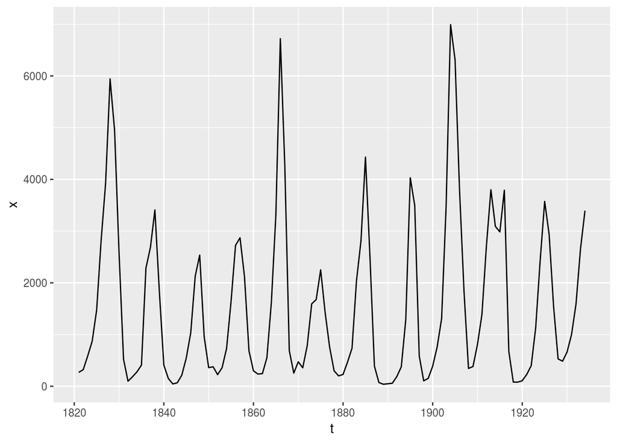

```r
ggplot(Tvalues, aes(x=t, y=x)) + geom_line()
```

### Exercise 1

Make a weekly time vector from 5 June 2005 to 20 August 2006. You should see:

```
##  [1] "2005-06-05" "2005-06-12" "2005-06-19" "2005-06-26" "2005-07-03"
##  [6] "2005-07-10" "2005-07-17" "2005-07-24" "2005-07-31" "2005-08-07"
## [11] "2005-08-14" "2005-08-21" "2005-08-28" "2005-09-04" "2005-09-11"
## [16] "2005-09-18" "2005-09-25" "2005-10-02" "2005-10-09" "2005-10-16"
## [21] "2005-10-23" "2005-10-30" "2005-11-06" "2005-11-13" "2005-11-20"
## [26] "2005-11-27" "2005-12-04" "2005-12-11" "2005-12-18" "2005-12-25"
## [31] "2006-01-01" "2006-01-08" "2006-01-15" "2006-01-22" "2006-01-29"
## [36] "2006-02-05" "2006-02-12" "2006-02-19" "2006-02-26" "2006-03-05"
## [41] "2006-03-12" "2006-03-19" "2006-03-26" "2006-04-02" "2006-04-09"
## [46] "2006-04-16" "2006-04-23" "2006-04-30" "2006-05-07" "2006-05-14"
## [51] "2006-05-21" "2006-05-28" "2006-06-04" "2006-06-11" "2006-06-18"
## [56] "2006-06-25" "2006-07-02" "2006-07-09" "2006-07-16" "2006-07-23"
## [61] "2006-07-30" "2006-08-06" "2006-08-13" "2006-08-20"
```

### Exercise 2

Download the file Practical7_time_series.txt and load it into R. This contains daily data on the internet traffic from November 20, 2004 until January 27, 2005.

- Add to the data a vector of the times corresponding to each data point
- Create a line plot of the amount of traffic per day
- From visually inspecting the plot, estimate the period of the seasonal trend. In other words, how often do you think the fluctuations occur?

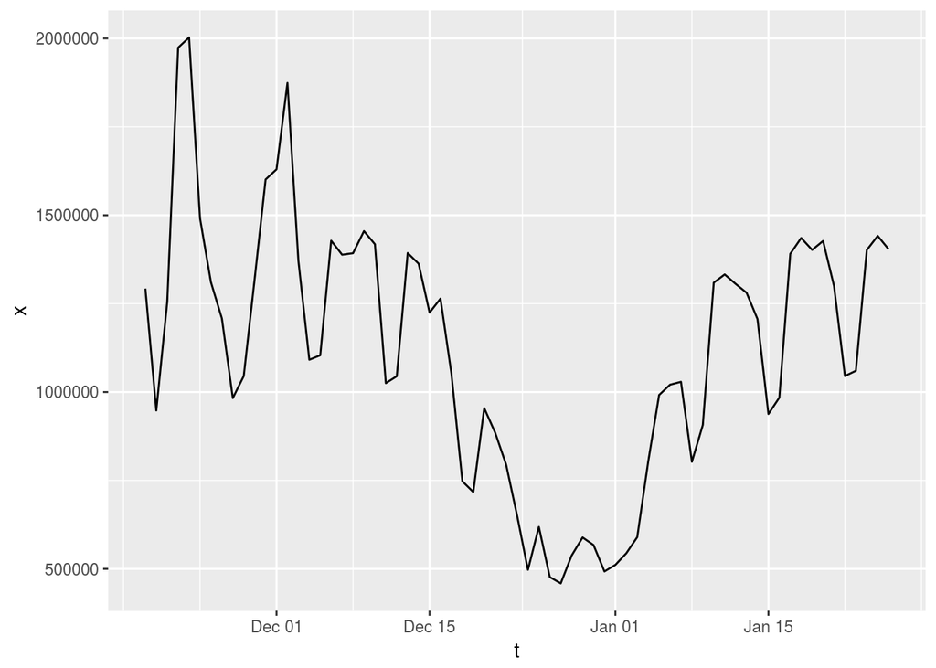

## Time Series Objects

### Using `ts()`

We can also use the `ts` function to create time series objects. The relevant syntax is shown below and you can learn more by typing `?ts` into the console.

```r
ts(data = NA, start = 1, end = numeric(), frequency = 1,
   deltat = 1)
```

Arguments:

- `data` - a vector or matrix of the observed time-series values.
- `start` - the time of the first observation. Either a single number or a vector of two integers, which specify a natural time unit and a (1-based) number of samples into the time unit. See the examples for the use of the second form.
- `end` - the time of the last observation, specified in the same way as start.
- `frequency` - the number of observations per unit of time. Some common examples of values are:
  - 12 - monthly data with a yearly cycle
  - 7 - daily data with a weekly cycle
  - 24 - hourly measurements within a day
- `deltat` - the fraction of the sampling period between successive observations; e.g., 1/12 for monthly data. Only one of `frequency` or `deltat` should be provided.

### Example

Here we use data from co2.csv which contains CO$_2$ measurements from the Mauna Loa observatory from January 1959 until December 1997, with values for each month.

Using `freq = 12` means that you have 12 observations per cycle (i.e. per year), so the period of the seasonal variation is just 12.

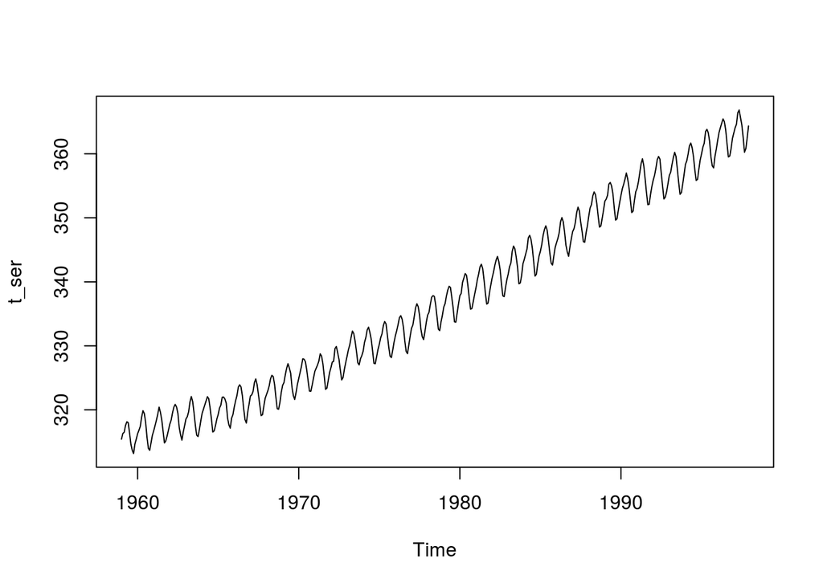

```r
co2_vals = read.csv("https://github.com/cbdavis/DASM/raw/master/2017/data/co2.csv")

t_ser <- ts(co2_vals$co2_ppm, start = c(1959, 1), freq = 12)
plot(t_ser)
```

You can also define a time series without a start date. Now the values on the x axis correspond to the cycle number, which in this case refers to the number of years after the first observation. Looking at the x axis, we see that there are nearly 40 years of observations.

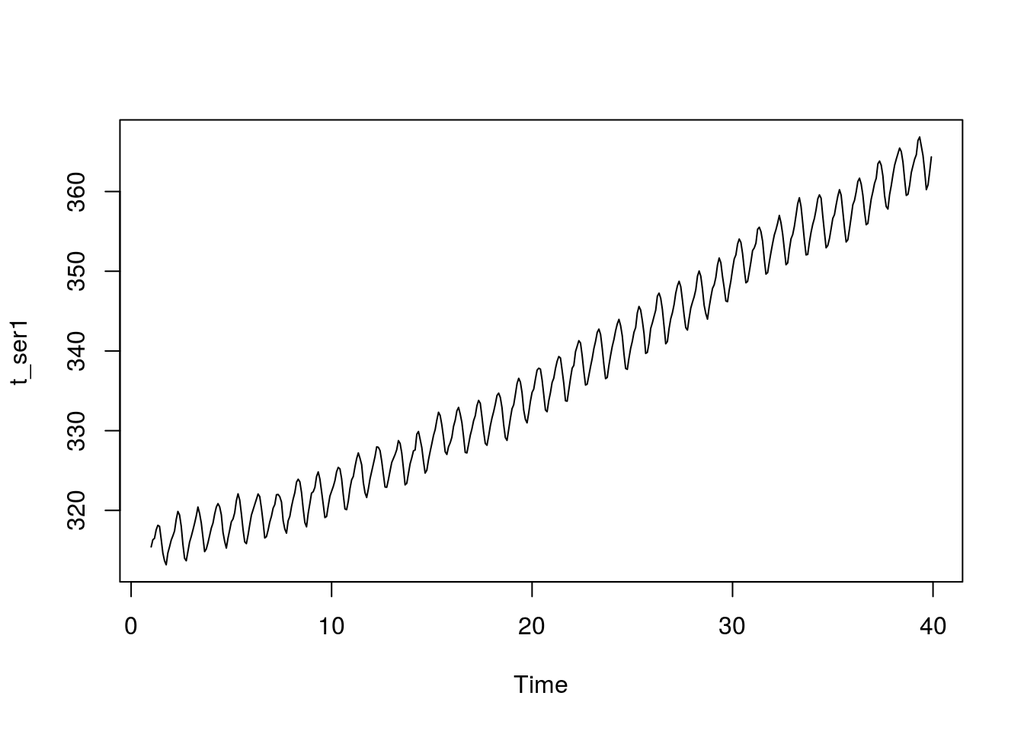

```r
t_ser1 <- ts(co2_vals$co2_ppm, freq = 12)
plot(t_ser1)
```

### Exercise

Using the data from Practical7_time_series.txt, make a time series out of it. Assume that the starting point is week 47.

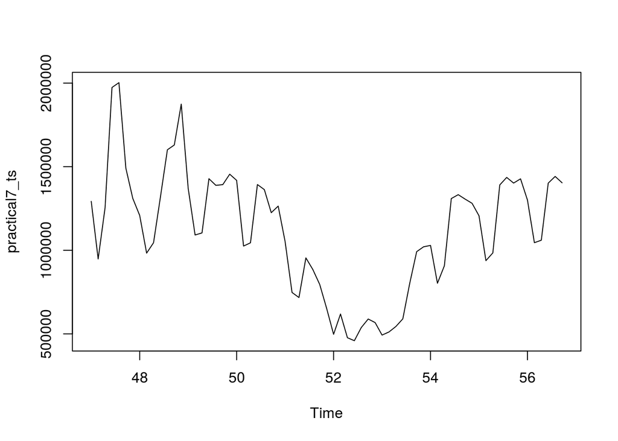

## Moving Average Smoothing

We will now use the `ma` function for moving-average smoothing. To do this, make sure to load the `forecast` library:

```r
library(forecast)
```

### Reminder

The formula for creating a moving average is:

- $T_{t} = \frac{1}{m} \sum_{j=-k}^{k} x(t + j)$
- Where $m = 2k + 1$

The main idea is that you take a set of $m$ data points with $k$ number of points to the left and $k$ to the right of $x(t)$ and average them with $x(t)$

The syntax is for the moving average function in R is:

```r
ma(x, order, centre=TRUE)
```

Arguments:

- `x` - Univariate time series
- `order` - Order of moving average smoother
- `centre` - If TRUE, then the moving average is centered for even orders.

### Example

Here we create a single moving average on the `lynx.csv` data we loaded in above.

```r
ma5 = ma(Tvalues$x, order = 5)
```

To demonstrate what is being calculated, the third element of the moving average is the average of elements 1:5 in the original data (k=2, so we include data 2 places to the left and right). The seventh element of the moving average is the average of elements 5:9 in the original data.

```r
ma5[3]
```

```
## [1] 704.2
```

```r
mean(Tvalues$x[1:5])
```

```
## [1] 704.2
```

```r
ma5[7]
```

```
## [1] 3823.4
```

```r
mean(Tvalues$x[5:9])
```

```
## [1] 3823.4
```

Here we can create a new data frame, where we add new columns to `Tvalues` that contain two moving averages. For this, we use the `dplyr` package along with the `mutate` function to add two new columns: `ma5` and `ma13`.

```r
Tvalues_with_ma = Tvalues %>%
  mutate(ma5 = ma(x, order = 5),
         ma13 = ma(x, order = 13))
```

Here we use `head` with `n=10` to look at the first ten rows of the resulting data frame:

```r
head(Tvalues_with_ma, n=10)
```

```
##       x          t    ma5     ma13
## 1   269 1821-01-01     NA       NA
## 2   321 1822-01-01     NA       NA
## 3   585 1823-01-01  704.2       NA
## 4   871 1824-01-01 1214.6       NA
## 5  1475 1825-01-01 1936.0       NA
## 6  2821 1826-01-01 3007.6       NA
## 7  3928 1827-01-01 3823.4 1888.077
## 8  5943 1828-01-01 4043.8 1888.846
## 9  4950 1829-01-01 3584.2 1895.615
## 10 2577 1830-01-01 2818.2 2026.385
```

We can now see the effects of the different values of `order` in the `ma` function. Specifically:

- `order = 5` means that 5 data points are averaged (2 to the left and right of the data point)
- `order = 13` means that 13 data points are averaged (6 to the left and right of the data point)

The first few values of `ma5` and `ma13` are `NA` due to this averaging on the left and right of the data point. For example, the first data point, does not have another data point to the left, so the average is defined as `NA`.

Now we can plot everything and see how the moving averages compare to the original data. Note that in the `geom_line` statements, we only specify the value for `y` since the data frame and `x` have already been specified with `ggplot(Tvalues_with_ma, aes(x=t))`

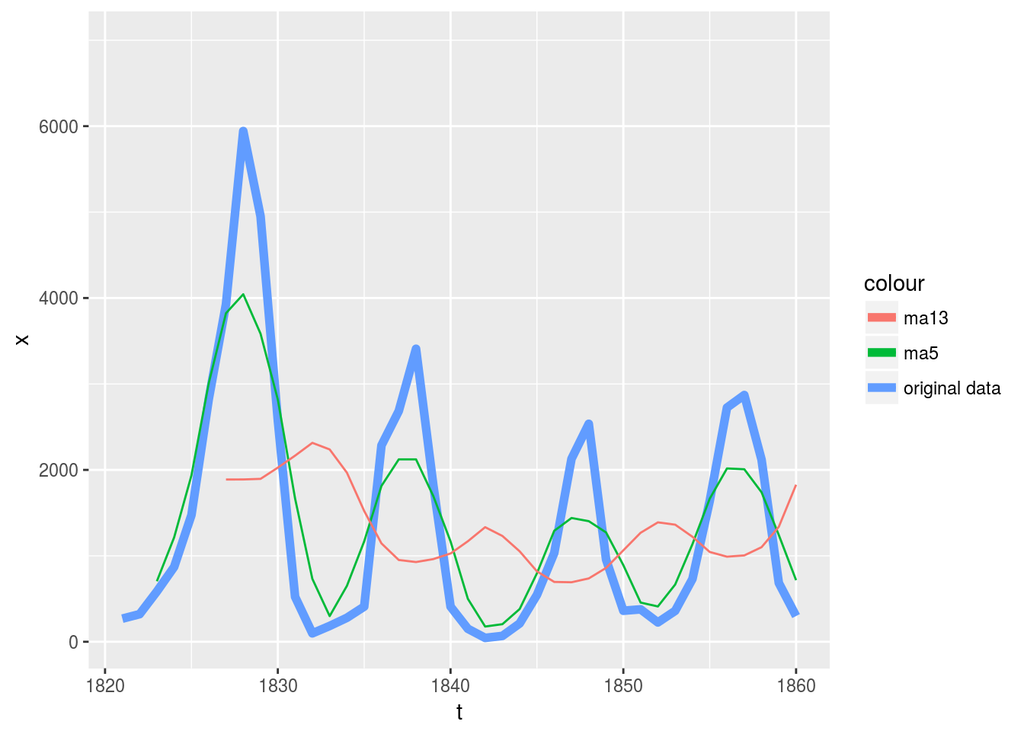

```r
ggplot(Tvalues_with_ma, aes(x=t)) +
  geom_line(aes(y=x, color="original data"), size=2) +
  geom_line(aes(y=ma5, color="ma5")) +
  geom_line(aes(y=ma13, color="ma13")) +
  xlim(c(as.Date("1821-01-01"),
         as.Date("1860-01-01"))) # Just show data from 1821-1860, otherwise the plot is too cluttered
```

### Exercise

Calculate a moving average with order = 3, 7, and 15 and add it to the plot.

Again use the data from Practical7_time_series.txt with the time values added in as shown above.

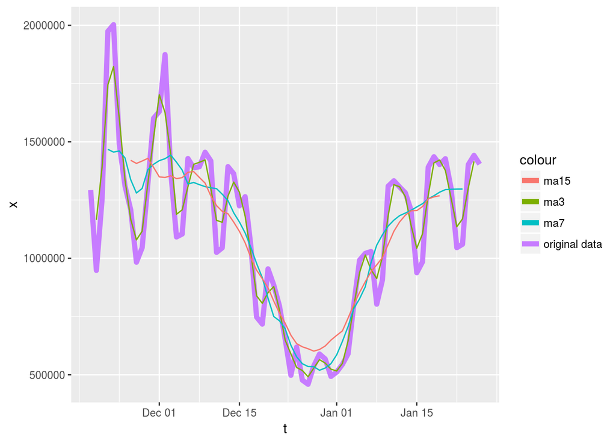

The warning messages that you see are related to `NA` values generated based on the different orders of moving averages.

## Lagging Time Values

Sometimes you want to calculate the difference between time series values where you offset one set of values by a particular time lag. For example, if you wanted to analyze the yearly growth of a country’s population, you would take the yearly population values and subtract them from the values for the previous years.

An easy way to do this is with the `lag` command and `dplyr`. The `lag` function simply takes as input a vector and shifts its values by the number specified. Take for example a vector containing the numbers 1, 2, …, 10:

```r
a = c(1:10)
print(a)
```

```
##  [1]  1  2  3  4  5  6  7  8  9 10
```

```r
lag(a, 3)
```

```
##  [1] NA NA NA  1  2  3  4  5  6  7
```

As you can see we push all the values over three places and fill in the left side with `NA`. The values 8, 9 and 10 are discarded since they are pushed out.

Here we shift the values for `co2_ppm` in `co2_vals` by three months. We use the `mutate()` function to create a new column named `lag_3` in the data frame.

```r
co2_vals_lag3 = co2_vals %>% mutate(lag_3 = lag(co2_ppm, 3))
```

Looking at the first few rows of the data frame, we can see how `NA` values are inserted at first, with the lagged values starting at row 4:

```r
head(co2_vals_lag3)
```

```
##   co2_ppm  lag_3
## 1  315.42     NA
## 2  316.31     NA
## 3  316.50     NA
## 4  317.56 315.42
## 5  318.13 316.31
## 6  318.00 316.50
```

Below we try to visually investigate if there might be a correlation between the original data and different lag amounts. In other words, if they are correlated, we would expect to see the points arranged in nearly a straight line.

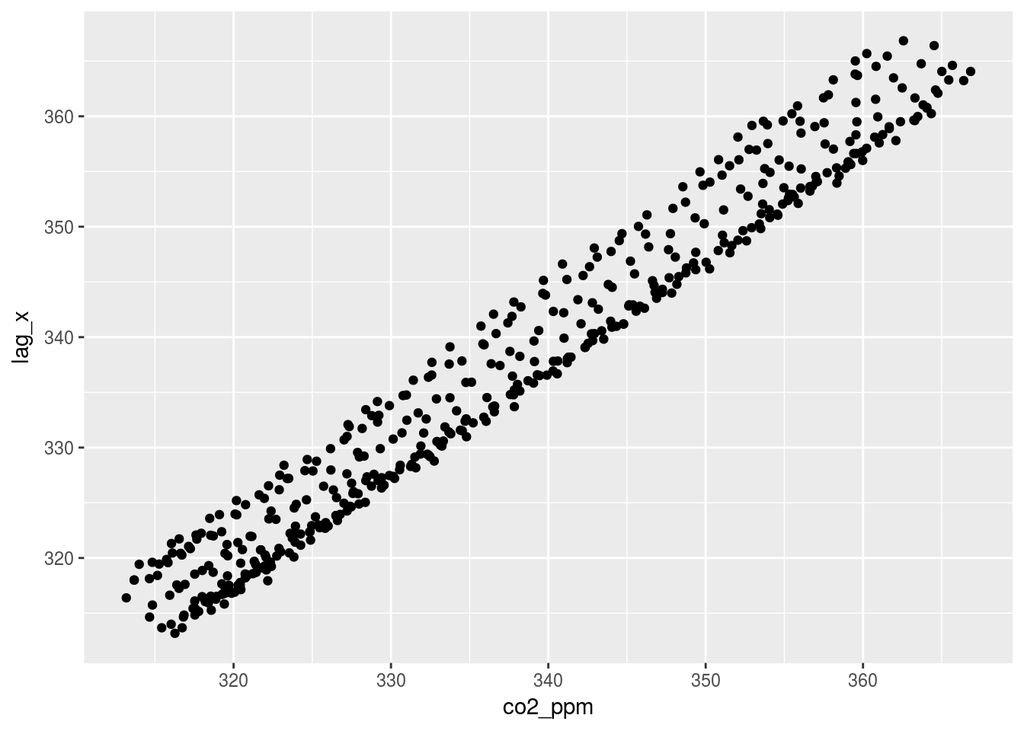

```r
## data shifted 3 months
ggplot(data = co2_vals %>% mutate(lag_x = lag(co2_ppm, 3)),
       aes(x=co2_ppm, y=lag_x)) +
  geom_point()
```

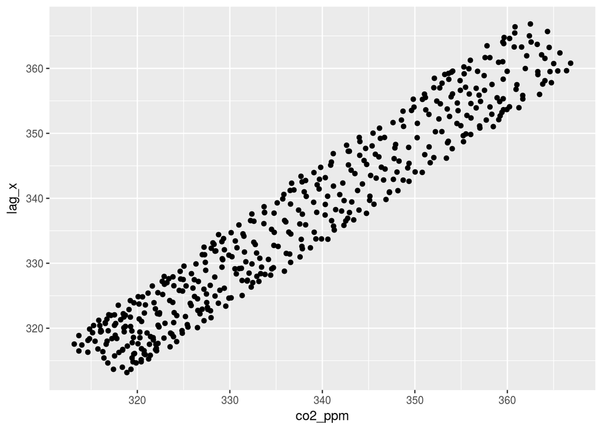

```r
## data shifted 6 months
ggplot(data = co2_vals %>% mutate(lag_x = lag(co2_ppm, 6)),
       aes(x=co2_ppm, y=lag_x)) +
  geom_point()
```

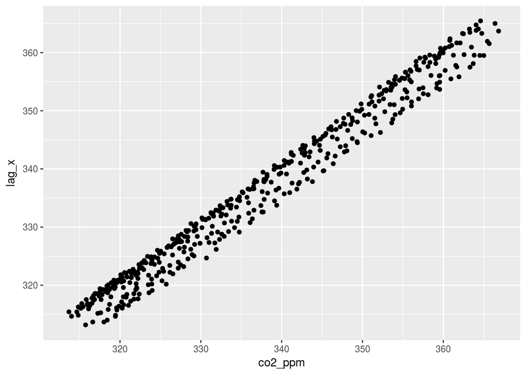

```r
## data shifted 10 months
ggplot(data = co2_vals %>% mutate(lag_x = lag(co2_ppm, 10)),
       aes(x=co2_ppm, y=lag_x)) +
  geom_point()
```

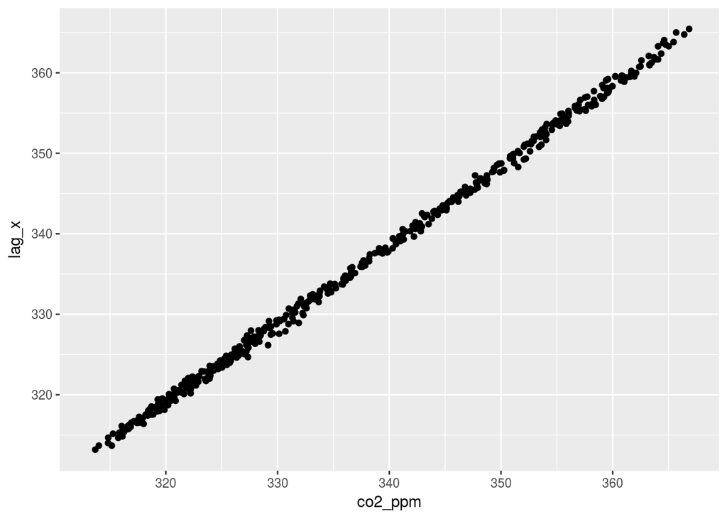

```r
## data shifted 12 months
ggplot(data = co2_vals %>% mutate(lag_x = lag(co2_ppm, 12)),
       aes(x=co2_ppm, y=lag_x)) +
  geom_point()
```

### Exercise

Again use the data from Practical7_time_series.txt with the time values added in as shown above. Using a lag of 10, show the actual correlation (scatter) plot.

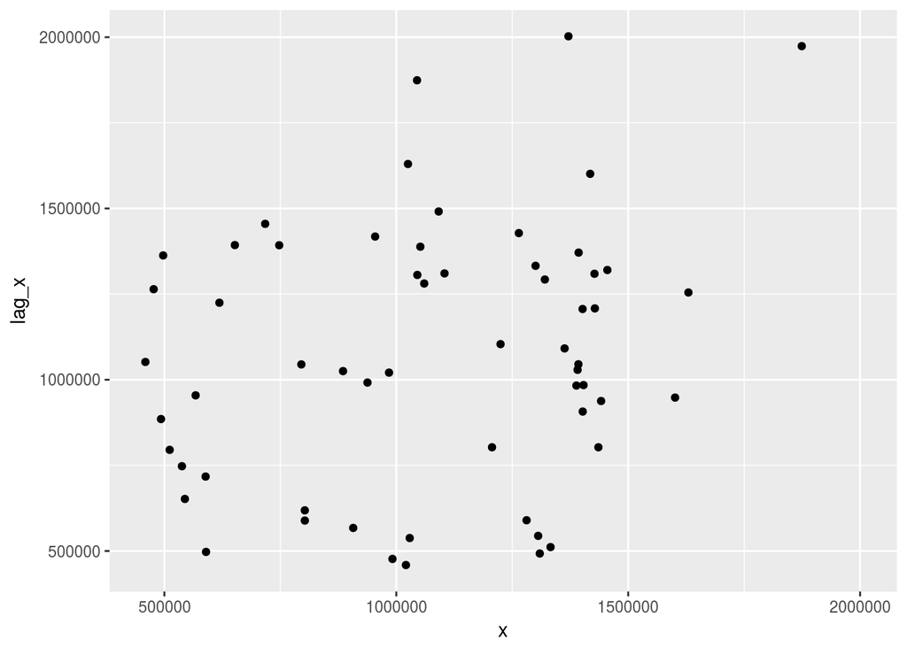

## Auto- and Cross- Covariance and -Correlation Function Estimation

### Reminder from the lecture

For a time series, a lag 1 correlation is a the correlation of the time series $x(t)$ with the time series shifted by one time unit $x(t + \Delta t)$

For the autocorrelation function we plot the auto-correlation coefficient $r(k*\Delta t)$ against the lag $k$

The basic syntax of the `acf` function is:

```r
acf(x, lag.max = NULL,
    type = c("correlation", "covariance", "partial"),
    plot = TRUE, na.action = na.fail)
```

Arguments:

- `x` - a univariate or multivariate numeric time series object or a numeric vector or matrix.
- `lag.max` - maximum lag at which to calculate the acf. Default is `10*log10(N/m)` where `N` is the number of observations and m the number of series. Will be automatically limited to one less than the number of observations in the series.
- `type` - character string giving the type of acf to be computed. Allowed values are `"correlation"` (the default), `"covariance"` or `"partial"`. Will be partially matched.
  - For this practical, we will only use `type="correlation"`.
- `plot` - logical. If TRUE (the default) the acf is plotted.
- `na.action` - function to be called to handle missing values. `na.pass` can be used.
  - One thing to be aware of is that the acf function will give an error of `Error in na.fail.default(as.ts(x)) : missing values in object` if one of the values in the data is `NA`. To get around this, you can add `na.action=na.pass`

### Example

Using the `lynx.csv` data, we estimate the autocorrelation with a maximum lag of 64.

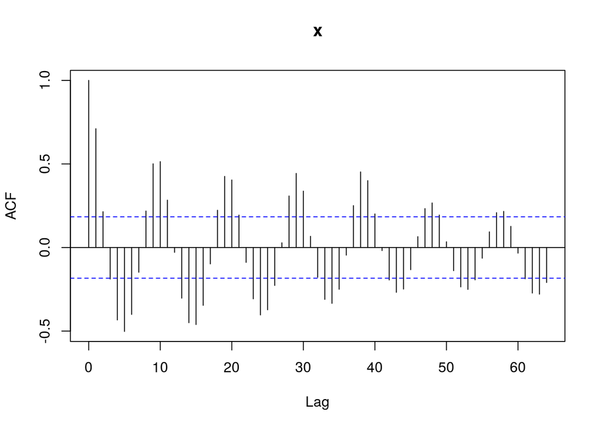

```r
Tvalues = read.csv("lynx.csv")
acf_T = acf(Tvalues,type = "correlation", lag.max = 64)
```

If you want to look at a specific value at a certain lag (say lag=10), you can use:

```r
acf_10 = acf_T$acf[10]
print(acf_10)
```

```
## [1] 0.500908
```

### Exercise

Calculate the autocorrelation function (ACF) of the time series data `Practical7_time_series.txt` and plot it with a maximum lag of 30.

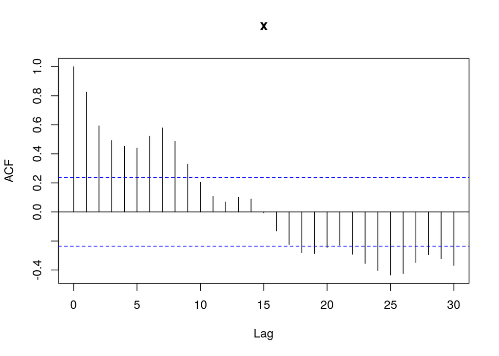